## Title: “Part 2: Analysis of the ToothGrowth data set”

*author: Ramaji*

*date: 19-MAR-2016*

## *Course: Statistical Inference*

The `ToothGrowth` data set contains the length of odontoblasts (teeth) in each of 10 guinea pigs at each of three dose levels of Vitamin C (0.5, 1, and 2 mg) with each of two delivery methods (orange juice or ascorbic acid). *[Ref.; C. I. Bliss (1952) The Statistics of Bioassay.Academic Press]*

### Quick exploration of the data set

For the purposes of this analysis, we will convert the dose variable into a factor.

```r
library(data.table)
library(knitr)
data(ToothGrowth)
tg<-as.data.table(ToothGrowth)
tgStat<-tg[,list(.N,mean(len),var(len)),by=list(supp,dose)]
colnames(tgStat)<-c("Supp","Dose","Size","Mean","Var")
kable(tgStat)
```

[output not shown]

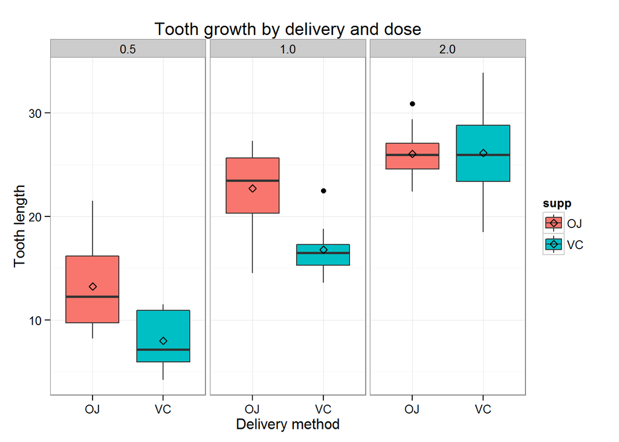

```r
library(ggplot2)
ggplot(data=tg, aes(y=len, x=supp, fill=supp)) + geom_boxplot() +
    facet_wrap(~ dose, ncol=3) + ylab("Tooth length") + xlab("Delivery method") +
    ggtitle("Tooth growth by delivery and dose") +
    stat_summary(fun.y=mean, geom="point", shape=5, size=2) +
    theme_bw()
```

At dose levels of 0.5 and 1.0 mg the mean tooth length has greater dispersion for those where orange juice was used. For the 2 mg level, no noticeable difference in the mean was observed, but the dispersion for the OJ group seems to be smaller than VC group.

### Multiple hypothesis testing

We will employ 2-sided unpaired t-tests to confirm whether there is a real difference between the groups by dose level and delivery method. We need to calculate the confidence intervals and p-values.

The comparison will be done at each dose level between delivery methods. Assume unequal variance. The p-values will be adjusted using the Bonferroni correction.

$H_0$ : There is no difference in the means between the two groups

```r
ts1 <- lapply(c(.5, 1, 2), function(x) {
    t.test(len ~ supp, data=subset(tg, dose==x), paired=FALSE, var.equal=FALSE)
    })
pvals <- c(ts1[[1]]$p.value, ts1[[2]]$p.value, ts1[[3]]$p.value)
stats <- c(ts1[[1]]$statistic, ts1[[2]]$statistic, ts1[[3]]$statistic)
pAdjusted <- p.adjust(pvals, method = "bonferroni")
llimit <- sapply(c(ts1[[1]]$conf.int[1], ts1[[2]]$conf.int[1], ts1[[3]]$conf.int[1]), round, 3)
ulimit <- sapply(c(ts1[[1]]$conf.int[2], ts1[[2]]$conf.int[2], ts1[[3]]$conf.int[2]), round, 3)
df <- data.frame(dose=c(0.5, 1, 2), t=stats, p=pvals, adj=pAdjusted,
                 confInt=paste0("[",paste(llimit, ulimit, sep=", "), "]"))
colnames(df) <- c("Dose", "tStat", "p-value", "Adj. p-value", "CI")
kable(df,format="markdown")
```

| Dose | tStat | p-value | Adj. p-value | CI |
| --- | --- | --- | --- | --- |
| 0.5 | 3.1697328 | 0.0063586 | 0.0190758 | [1.719, 8.781] |
| 1.0 | 4.0327696 | 0.0010384 | 0.0031151 | [2.802, 9.058] |
| 2.0 | -0.0461361 | 0.9638516 | 1.0000000 | [-3.798, 3.638] |

### Conclusions

- We find the adjusted p-values are significant at the $\alpha$ = 0.05 level, and, the 95% confidence intervals do not include zero. At the dosage levels of 0.5 and 1 mg we find that there is statistically significant difference between the means of the OJ and VC groups.
- For the 2 mg dosage level we find the adjusted p-value to be much greater than 0.5, and the 95% confidence interval includes zero. Hence we fail to reject the null hypothesis. It seems that at Vitamin C level, there is no significance influence of the delivery method on tooth growth in guinea pigs.
- We find, for testing the 2mg level, the current sample size of 10 is very small to provide any siginificant difference. We will need a much bigger sample size. Let us calculate the minimum sample size needed.

```r
groupSd <- sqrt(((tgStat$Size[3]-1)*tgStat$Var[3]+(tgStat$Size[6]-1)*tgStat$Var[6])/(tgStat$Size[3]+tgStat$Size[6]-2))
estSize <- round(power.t.test(power=0.9,delta=(tgStat$Mean[6]-tgStat$Mean[3]),sd=groupSd)$n,0)
cat("Effect error size:", round((tgStat$Mean[3]-tgStat$Mean[6])/groupSd, 3),"\nEstimated Size:",estSize)
```

```
## Effect error size: 0.021
## Estimated Size: 49365
```